# ЕГЭ 2017 Вариант 1702 EGE 2017 Variant 1702

### Использованы задания [ЕГЭ-2017. Вариант 1702 . Д. В. Богданов](http://ege-inf.ru/dow/EGE_inf_1702.pdf)

## Полезные ссылки

### Информатика. 10 класс. Углубленный уровень. В 2 ч. Поляков К.Ю., Еремин Е.А. [Часть 1](https://drive.google.com/file/d/0B6696ckkWj_zVUZBbVNrS2hCWFE/view) [Часть 2](https://drive.google.com/file/d/0B6696ckkWj_zOU9zWFVGeU03QUU/view)

### Python [Online](https://www.python.org/shell/)

## Часть 1 Part 1

```python
%%html
<style>
@import url('https://fonts.googleapis.com/css?family=Roboto&effect=3d|scuffed-steel|static|brick-sign|canvas-print|');
body {background-color: aliceblue;}
a {color: #4876ff; font-family: 'Roboto';}
h1 {color: #348ABD; font-family: 'Roboto'; text-shadow: 4px 4px 4px #aaa;}
h2, h3 {color: gray; font-family: 'Roboto'; text-shadow: 4px 4px 4px #aaa;}
h4 {color: #348ABD; font-family: 'Roboto';}
span {text-shadow: 4px 4px 4px #aaa;}
div.output_prompt, div.output_area pre, div.output_subarea {color: gray;}
div.input_prompt {color: #4876ff;}
div.output_stderr pre {background-color: aliceblue;}
div.output_stderr {background-color: gray;}
</style>
```

```python
answer_dictionary = dict()
```

#### Задание 1

Сколько целочисленных решений у неравенства $6GF_{19} < 𝑥 < G60_{19}$?

```python
# from 19-based system to decimal
int('6GF',19), int('G60',19)
```

```
(2485, 5890)
```

```python
# 6GF to decimal
6 * 19 ** 2 + 16 * 19 + 15
```

```
2485
```

```python
# G60 to decimal
16 * 19 ** 2 + 6 * 19 + 0
```

```
5890
```

```python
answer_dictionary[1]=str(int('G60',19) - int('6GF',19) - 1)
print ("Answer:",answer_dictionary[1])
```

```
Answer: 3404
```

#### Задание 2

Логическая функция 𝑓 задаётся выражением:

$𝑓(𝑥_1, . . . , 𝑥_6) = (𝑥_4 \lor \neg 𝑥_5 \lor 𝑥_6) \land ((\neg 𝑥_1 \equiv 𝑥_2) \lor (𝑥_3 \to 𝑥_4))$.

Сколько строк в таблице истинности функции 𝑓 соответствуют условию,

что функция 𝑓 ложна, если ровно три из её шести аргументов $𝑥_1, ..., 𝑥_6$ также имеют значение "ложь"?

```python
%%latex
$𝑓(𝑥_1, . . . , 𝑥_6) = 0 \iff \\
((𝑥_4 \lor \neg 𝑥_5 \lor 𝑥_6) = 0) \lor ((\neg 𝑥_1 \equiv 𝑥_2) \lor (𝑥_3 \to 𝑥_4) = 0) \iff \\
((𝑥_4 = 0 \land 𝑥_5 = 1 \land 𝑥_6 = 0) \lor (\neg 𝑥_1 \equiv 𝑥_2 = 0) \land (𝑥_3 \to 𝑥_4 = 0)) \iff \\
((𝑥_4 = 0 \land 𝑥_5 = 1 \land 𝑥_6 = 0) (*) \lor ((𝑥_1 = 𝑥_2 = 0 \lor 𝑥_1 = 𝑥_2 = 1) \land (𝑥_3 = 1 \land 𝑥_4 = 0) (**)$
```

$𝑓(𝑥_1, . . . , 𝑥_6) = 0 \iff \\ ((𝑥_4 \lor \neg 𝑥_5 \lor 𝑥_6) = 0) \lor ((\neg 𝑥_1 \equiv 𝑥_2) \lor (𝑥_3 \to 𝑥_4) = 0) \iff \\ ((𝑥_4 = 0 \land 𝑥_5 = 1 \land 𝑥_6 = 0) \lor (\neg 𝑥_1 \equiv 𝑥_2 = 0) \land (𝑥_3 \to 𝑥_4 = 0)) \iff \\ ((𝑥_4 = 0 \land 𝑥_5 = 1 \land 𝑥_6 = 0) (*) \lor ((𝑥_1 = 𝑥_2 = 0 \lor 𝑥_1 = 𝑥_2 = 1) \land (𝑥_3 = 1 \land 𝑥_4 = 0) (**)$

Выполняется `(*), (**)`

- `0,0,1,0,1,0`
- `1,1,1,0,1,0`

Выполняется `(**)`

- `0,0,1,0,0,0`
- `1,1,1,0,0,0` - # 1
- `0,0,1,0,0,1`
- `1,1,1,0,0,1`
- `0,0,1,0,1,1` - # 2
- `1,1,1,0,1,1`

Выполняется `(*)`

- `0,0,0,0,1,0`
- `0,1,0,0,1,0`
- `1,0,0,0,1,0`
- `1,1,0,0,1,0` - # 3
- `0,1,1,0,1,0` - # 4
- `1,0,1,0,1,0` - # 5

```python
# Check the decision method
import itertools, numpy
from sympy.logic.boolalg import Implies

n = 6
binary_combinations = numpy.array(list(itertools.product([0, 1], repeat=n)))
result = []

def logical_function(x1,x2,x3,x4,x5,x6):
    return bool( (x4 or (not x5) or x6) and (((not x1) == x2) or (Implies(x3,x4))))

for el in binary_combinations:
    if (sum(el) == 3) and (logical_function(el[0],el[1],el[2],el[3],el[4],el[5]) == 0):
        print(el)
        result.append(el)

answer_dictionary[2]=str(len(result))
print("Answer:", answer_dictionary[2])
```

```
[0 0 1 0 1 1]
[0 1 1 0 1 0]
[1 0 1 0 1 0]
[1 1 0 0 1 0]
[1 1 1 0 0 0]
Answer: 5
```

#### Задание 3

Между городами $𝑣_1, ..., 𝑣_8$ построены дороги, протяжённость которых приведена в таблице. Отсутствие числа в таблице означает, что прямой дороги между городами нет.

| - | $𝑣_1$ | $𝑣_2$ | $𝑣_3$ | $𝑣_4$ | $𝑣_5$ | $𝑣_6$ | $𝑣_7$ | $𝑣_8$ |
| --- | --- | --- | --- | --- | --- | --- | --- | --- |
| $𝑣_1$ | - | 4 | 5 | - | 8 | - | - | - |
| $𝑣_2$ | - | - | 2 | 6 | - | - | - | - |
| $𝑣_3$ | - | - | - | - | 3 | 2 | - | - |
| $𝑣_4$ | 13 | - | - | - | - | 1 | 5 | - |
| $𝑣_5$ | - | - | - | - | - | 1 | - | 9 |
| $𝑣_6$ | - | - | - | - | - | - | 3 | 6 |
| $𝑣_7$ | - | - | - | - | - | - | - | 2 |
| $𝑣_8$ | - | 3 | 5 | 6 | - | 7 | 8 | - |

Определите длину кратчайшего пути из города $𝑣_1$ до самого дальнего от него города.

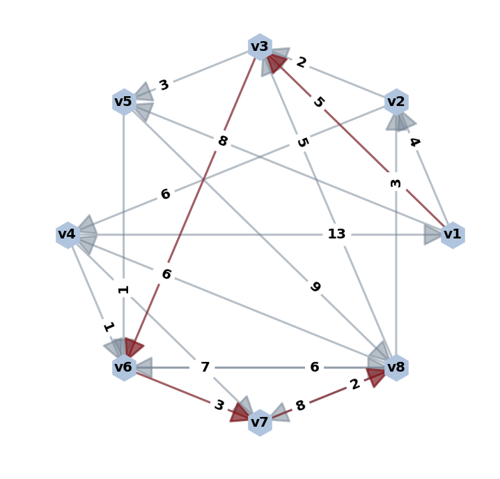

```python
import networkx as nx
import matplotlib.pyplot as plt
%matplotlib inline

G = nx.MultiDiGraph()
plt.figure(figsize=(12,12))

G.add_weighted_edges_from([('v1','v2',4), ('v1','v3',5), ('v1','v5',8)])
G.add_weighted_edges_from([('v2','v3',2), ('v2','v4',6)])
G.add_weighted_edges_from([('v3','v5',3), ('v3','v6',2)])
G.add_weighted_edges_from([('v4','v1',13), ('v4','v6',1), ('v4','v7',5)])
G.add_weighted_edges_from([('v5','v6',1), ('v5','v8',9)])
G.add_weighted_edges_from([('v6','v7',3), ('v6','v8',6)])
G.add_weighted_edges_from([('v7','v8',2)])
G.add_weighted_edges_from([('v8','v2',3), ('v8','v3',5), ('v8','v4',6), ('v8','v6',7), ('v8','v7',8)])

pos=nx.shell_layout(G)

nx.draw_networkx_edges(G, pos, width=3,
                       alpha=0.5, edge_color='slategray',
                       arrowsize=70, arrowstyle='-|>')
nx.draw_networkx_nodes(G, pos, node_size=1500,
                       node_shape='h', node_color='lightsteelblue')
nx.draw_networkx_labels(G, pos, font_size=20, font_weight='bold')

edge_labels = dict([((u,v,),d['weight']) for u,v,d in G.edges(data=True)])
nx.draw_networkx_edge_labels(G,pos,font_size=20,font_weight='bold',
                             label_pos=0.3, edge_labels=edge_labels)

path_edges = [('v1','v3'), ('v3','v6'), ('v6','v7'), ('v7','v8')]

nx.draw_networkx_edges(G, pos, width=3, edgelist=path_edges,
                       alpha=0.5, edge_color='darkred',
                       arrowsize=70, arrowstyle='-|>')
plt.axis('off')
plt.show()
```

```python
nx.shortest_path(G,'v1',weight='weight')
```

```
{'v1': ['v1'],
 'v2': ['v1', 'v2'],
 'v3': ['v1', 'v3'],
 'v4': ['v1', 'v2', 'v4'],
 'v5': ['v1', 'v5'],
 'v6': ['v1', 'v3', 'v6'],
 'v7': ['v1', 'v3', 'v6', 'v7'],
 'v8': ['v1', 'v3', 'v6', 'v7', 'v8']}
```

```python
length = G['v1']['v3'][0]['weight'] + G['v3']['v6'][0]['weight'] + \
         G['v6']['v7'][0]['weight']+ G['v7']['v8'][0]['weight']
```

```python
answer_dictionary[3]=str(length)
print("Answer:", answer_dictionary[3])
```

```
Answer: 12
```

#### Задание 4

Во фрагменте базы данных сохранено дерево разбора некоторого арифметического выражения. На основании приведённых данных укажите значение 𝑎, при котором значение выражения будет наименьшим.

| ID | ID_родителя | Значение |
| --- | --- | --- |
| 1 | 4 | 𝑎 |
| 2 | 3 | 𝑎 |
| 3 | 4 | + |
| 4 | 0 | * |
| 5 | 3 | – |
| 6 | 5 | 2 |

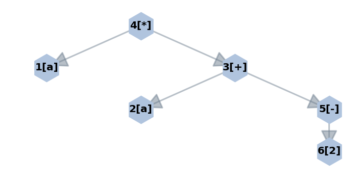

```python
import pydot
from networkx.drawing.nx_pydot import graphviz_layout

plt.figure(figsize=(12,6))
G2 = nx.DiGraph()

G2.add_edges_from([('4[*]','1[a]'), ('4[*]','3[+]')])
G2.add_edges_from([('3[+]','2[a]'), ('3[+]','5[-]')])
G2.add_edges_from([('5[-]','6[2]')])

pos = graphviz_layout(G2, prog='dot')

nx.draw_networkx_edges(G2, pos, width=3, alpha=0.5, edge_color='slategray',
                       arrowsize=70, arrowstyle='-|>')
nx.draw_networkx_nodes(G2, pos, node_size=3000, node_shape='h', node_color='lightsteelblue')
nx.draw_networkx_labels(G2, pos, font_size=20, font_weight='bold')

plt.axis('off')
plt.show()
```

```python
%%latex
$a * ( a + (-2)) = a^2 - 2 * a \\
\begin{cases}
(a^2 - 2 * a)' = 2 * a - 2 = 0 \\
(a^2 - 2 * a)'' = 2 > 0
\end{cases}
\iff a = 1$
```

$a * ( a + (-2)) = a^2 - 2 * a \\ \begin{cases} (a^2 - 2 * a)' = 2 * a - 2 = 0 \\ (a^2 - 2 * a)'' = 2 > 0 \end{cases} \iff a = 1$

```python
answer_dictionary[4]=str(1)
print("Answer:", answer_dictionary[4])
```

```
Answer: 1
```

#### Задание 5

Для передачи сообщений по каналу связи используется равномерный двоичный код. Каждому символу исходного алфавита соответствует 5-битовое кодовое слово. Для набора кодовых слов выполнено следующее свойство (важное для расшифровки сообщений при наличии помех): любые два слова из набора отличаются не менее чем в трёх позициях. Известно, что одному из символов исходного алфавита соответствует кодовое слово `10101`. Сколько таких кодовых слов, которые однозначно не будут использованы в данном наборе?

Кодовых слов, отличающихся от данного только одним символом, может быть только пять: не совпадает первый, второй, третий, четвертый или пятый символ. Кодовых слов, отличающихся на два символа, будет десять: не совпадают 1 и 2, 1 и 3, 1 и 4, 1 и 5, 2 и 3, 2 и 4, 2 и 5, 3 и 4, 3 и 5, 4 и 5 символы. Всего получается 5+10=15 кодовых слов.

```python
# Check the decision method
n = 5
binary_combination = numpy.array([1,0,1,0,1])
binary_combinations = numpy.array(list(itertools.product([0, 1], repeat=n)))
result = []

for el in binary_combinations:
    if (sum(el == binary_combination) > 2 and sum(el == binary_combination) < 5):
        print(el)
        result.append(el)

answer_dictionary[5]=str(len(result))
print("Answer:", answer_dictionary[5])
```

```
[0 0 0 0 1]
[0 0 1 0 0]
[0 0 1 0 1]
[0 0 1 1 1]
[0 1 1 0 1]
[1 0 0 0 0]
[1 0 0 0 1]
[1 0 0 1 1]
[1 0 1 0 0]
[1 0 1 1 0]
[1 0 1 1 1]
[1 1 0 0 1]
[1 1 1 0 0]
[1 1 1 0 1]
[1 1 1 1 1]
Answer: 15
```

#### Задание 6

Автомат получает на вход натуральное число 𝑥, состоящее из 𝑛 ≥ 2 цифр, все цифры числа 𝑥 отличны от нуля. Новое число 𝑦 строится по следующим правилам:

1) Для каждой пары соседних цифр из 𝑥 вычисляется их наименьшее общее кратное (НОК).

2) Полученные значения НОК записываются в порядке невозрастания (без разделителей).

*Пример*. Исходное число: 143. HOK (1, 4) = 4; HOK (4, 3) = 12. Результат: 124. Укажите наибольшее число, при обработке которого автомат выдаёт результат 4221.

Из 4221 можно получить невозрастающие последовательности НОК: 4,2,2,1 или 42,2,1 или 42,21. Исходное число в первом случае будет пятизначным, во втором - четырехзначным и в третьем - трехзначным. Пятизначное заведомо больше всех остальных, поэтому можно рассматривать только первый вариант.

`4, 2, 2, 1`

1. HOK(1, 4) = 4, HOK(2, 4) = 4, HOK(4, 4) = 4
2. HOK(1, 2) = 2, HOK(2, 2) = 2
3. HOK(1, 1) = 1

Среди всех вариантов множителей (1,2,4) выбираем максимально возможное для первой цифры значение - 4, для второй - 2, для третьей - 2, для четвертой и пятой - 1 и 1. Исходное число равно 42211.

```python
answer_dictionary[6]=str(42211)
print("Answer:", answer_dictionary[6])
```

```
Answer: 42211
```

#### Задание 7

В ячейке A4 электронной таблицы записана формула `=ЕСЛИ(И(2*A1>A2; A2=3*A3); "да"; "нет")`. Какое наименьшее целое значение могло быть записано в ячейке A1, если значения в ячейках A3 и A4 соответственно равны 10 и "да"?

[Google Sheet](https://drive.google.com/open?id=1SzLIezt9sDxcTNnMj0e5vba9XM7HuKpQD-jc7BqHaFg)

[figure not shown]

```python
answer_dictionary[7]=str(16)
print("Answer:", answer_dictionary[7])
```

```
Answer: 16
```

#### Задание 8

Запишите число, которое будет напечатано в результате выполнения следующей программы.

Паскаль

Си http://cpp.sh/

Бейсик

Python

```bash
var a, b, p , q : integer;
begin
    p := 0; q := 0;
    a := 5; b := 4;
    repeat
        p := p + a; q := q + b;
        a := a + 35; b := b * 2;
    until p = q;
    write(p)
end;
```

```bash
#include <stdio.h>
void main() {
int p = 0, q = 0;
int a = 5, b = 4;
do {
p += a; q += b;
a += 35; b *= 2;
} while (p != q);
printf("%d", p);
}
```

```bash
DIM P, Q, A, B AS INTEGER
P = 0 : Q = 0
A = 5 : B = 4
DO
P = P + A : Q = Q + B
A = A + 35 : B = B * 2
LOOP WHILE P <> Q
PRINT P
```

```bash
p = q = 0
a, b = 5, 4
while True :
    p, q = p + a, q + b
    a, b = a + 35, b * 2
    if p == q :
        break
print(p)
```

```python
p = q = 0
a, b = 5, 4
while True :
    p, q = p + a, q + b
    a, b = a + 35, b * 2
    if p == q :
        break
print(p)
```

```
1020
```

```python
answer_dictionary[8]=str(p)
print("Answer:", answer_dictionary[8])
```

```
Answer: 1020
```

#### Задание 9

Время передачи одноканальной (моно) звукозаписи с частотой дискретизации 48 кГц и 16-битным разрешением по каналу связи с пропускной способностью 6000 КБайт/сек. оказалось в два раза большим, чем время передачи изображения размером 1024 × 1024 пикселей в цветовой модели RGB по каналу связи с пропускной способностью 2 МБайт/сек. Определите длительность звукозаписи, ответ дайте в секундах.

```python
# 1024 X 1024 X 24 - the image size in RGB (3 * 8 bits)
# 3 * 2 ^ 23
2**10 * 2 **10 * 24
```

```
25165824
```

```python
# the time for image transmission with the speed = 2 Mbytes/sec
# 3 / 2
3 * 2 ** 23 / (2 * 2**20 * 2 ** 3)
```

```
1.5
```

```python
# the time for sound transmission (twice the speed image transmission)
# 3 / 2 * 2
3 / 2 * 2
```

```
3.0
```

```python
# the sound file size
# 3 * 48000 * 2 ^ 10
3 * 6000 * 2 ** 10 * 2 ** 3
```

```
147456000
```

```python
# the sound file size
3 * 48000 * 2 ** 10 / (48000 * 16)
```

```
192.0
```

```python
answer_dictionary[9]=str(192)
print("Answer:", answer_dictionary[9])
```

```
Answer: 192
```

#### Задание 10

Сколько существует различных символьных последовательностей длины 5, которые содержат ровно 3 символа из алфавита {𝐴, 𝐵} и 2 символа из алфавита {𝐶, 𝐷, 𝐸, 𝐹}?

Количество вариантов размещения 3 символов из алфавита {𝐴, 𝐵} по 5 возможным местам в последовательности равно $\large {\frac {5!} {3! * (5-3)!}}$:

- 1,2,3; 1,2,4; 1,2,5 и т.д.

Количество наборов, которые можно составить из 3 символов множества {𝐴, 𝐵}, равно $ 2^3 $:

- 𝐴,𝐴,𝐴; 𝐴,𝐴,𝐵; 𝐴,𝐵,𝐴 и т.д.

Если 3 символа последовательности из 5 уже размещены, остальные 2 символа из алфавита {𝐶, 𝐷, 𝐸, 𝐹} распределяются по 2 оставшимся местам только одним способом. Например, если уже есть символы в 1, 3 и 5 позиции, другие можно поставить только на 2 и 4 место.

Количество наборов, которые можно составить из 2 символов множества {𝐶, 𝐷, 𝐸, 𝐹}, равно: $ 4^2 $:

- 𝐶,𝐶,𝐶,𝐶; 𝐶,𝐶,𝐶,𝐷; 𝐶,𝐶,𝐶,𝐸 и т.д.

Выбор 3 символов из {𝐴, 𝐵} и 2 символов {𝐶, 𝐷, 𝐸, 𝐹} происходит независимо, учитываются все возможные наборы и их размещение, то есть их количество необходимо перемножить.

Общее число вариантов будет равно:

$ \large {\frac {5!} {3! * (5-3)!}}$ $* 2 ^ 3 * 4 ^ 2 $

```python
answer_dictionary[10]=str(int(((5 * 4 * 3 * 2)/(3 * 2 * 2)) * 2 ** 3 * 4 ** 2))
print("Answer:", answer_dictionary[10])
```

```
Answer: 1280
```

#### Задание 11

Ниже на четырёх языках записаны рекурсивные алгоритмы F и G.

При каком наименьшем целом значении 𝑝 значение функции G(𝑝) окажется больше 500?

Паскаль

Си http://cpp.sh/

Бейсик

Python

```bash
function F(n, k : integer) : integer;
begin
    if k > 0 then
        F := n * F(n, k - 1)
    else
        F := 1
end;

function G(n : integer) : integer;
begin
    if n > 0 then
        G := G(n - 1) + F(n, n - 1)
    else
        G := 0
end;
```

```bash
int F(int n, int k) {
    if (k > 0)
        return n * F(n, k - 1);
    else
        return 1;
}

int G(int n) {
    if (n > 0)
        return G(n-1) + F(n, n-1);
    else
        return 0;
}
```

```bash
FUNCTION F(N, K)
    IF K > 0 THEN
        F = N * F(N, K - 1)
    ELSE
        F = 1
END IF
END FUNCTION

FUNCTION G(N)
    IF N > 0 THEN
        G = G(N - 1) + F(N, N - 1)
    ELSE
        G = 0
END IF
END SUB
```

```bash
def F(n, k):
    if k > 0:
        return n * F(n, k - 1)
    else:
        return 1

def G(n):
    if n > 0:
        return G(n - 1) + F(n, n - 1)
    else:
        return 0
```

```python
def F(n, k):
    if k > 0: return n * F(n, k - 1)
    else: return 1

def G(n):
    if n > 0: return G(n - 1) + F(n, n - 1)
    else: return 0
```

```python
for i in range(1,6):
    print('i = ', i, 'F:', F(i, i-1), 'G:', G(i))
```

```
i =  1 F: 1 G: 1
i =  2 F: 2 G: 3
i =  3 F: 9 G: 12
i =  4 F: 64 G: 76
i =  5 F: 625 G: 701
```

```python
answer_dictionary[11]=str(5)
print("Answer:", answer_dictionary[11])
```

```
Answer: 5
```

#### Задание 12

В двоичной записи IP-адреса узла содержится 20 единиц, а в двоичной записи соответствующего адреса сети — 20 нулей. Каково наименьшее возможное общее количество нулей во всех четырёх байтах маски?

В бинарной записи IP-адреса узла содержится 20 единиц и 12 нулей (всего 32 разряда), в записи соответствующего адреса сети - 12 единиц и 20 нулей (на 8 единиц меньше, чем в IP-адресе).

Адрес сети получается в результате применения поразрядной конъюнкции к заданному IP-адресу узла и маске. Это означает, что в бинарной записи маски содержится как минимум 8 нулей, причем в тех разрядах, где в бинарной записи IP-адреса узла - единицы, а в записи соответствующего адреса сети - нули.

Нулей в бинарной записи маски может быть и больше, если они располагаются в тех разрядах, где и в бинарной записи IP-адреса узла, и в адресе сети стоят нули.

```python
answer_dictionary[12]=str(8)
print("Answer:", answer_dictionary[12])
```

```
Answer: 8
```

#### Задание 13

Для хранения длинных чисел можно использовать алгоритм кодирования повторов `(RLE)`, который заменяет повторяющиеся цифры (серии) на число повторов цифры и саму цифру. Например, число `5999` после сжатия станет числом `1539`. Если длина серии превосходит 9, она разбивается на несколько серий длиной 9 и, возможно, ещё одну длиной меньше 9. После сжатия производится поразрядное кодирование, все цифры кодируются одинаковым и минимально возможным количеством бит.

Сколько байт потребуется для сжатия и кодирования указанным способом числа `12 300 000 000 000 555`?

Закодируем исходное число указанным способом: $12300000000000555 \to 111213902035$ - одна единица, одна двойка, одна тройка, девять нулей, оставшиеся два нуля, три пятерки.

Для кодирования каждой из 10 цифр требуется $ \log_2{10} \approx 3.32 \approx 4$ бита. Округление в данном случае всегда происходит в большую сторону: вариантов должно быть достаточно для однозначного кодирования всех символов.

Для поразрядного кодирования 12 получившихся цифр требуется $12 * 4 = 48$ (бит) или $48 / 2^3 = 6$ (байт).

```python
import math
answer_dictionary[13]=str(int(math.ceil(math.log(10,2))*12/2**3))
print("Answer:", answer_dictionary[13])
```

```
Answer: 6
```

#### Задание 14

Исполнитель Шифровщик производит поразрядное преобразование натуральных десятичных чисел, используя представленную ниже таблицу шифрования.

| **Исходная цифра** | 0 | 1 | 2 | 3 | 4 | 5 | 6 | 7 | 8 | 9 |
| --- | --- | --- | --- | --- | --- | --- | --- | --- | --- | --- |
| **Результат шифрования** | 6 | 3 | 1 | 4 | 8 | 9 | 0 | 5 | 2 | 7 |

*Пример.* Исходное число: 1025. Преобразование разрядов: 1 → 3, 0 → 6, 2 → 1, 5 → 9. Результат: 3619.

Какое наименьшее число раз необходимо последовательно преобразовать исходное число 16845 с помощью Шифровщика, чтобы в результате было получено число 86319?

Каждый разряд исходного числа преобразуется следующим образом:

- `1 → 3 → 4 → 8 → 2 → 1 → 3 → 4 → 8` ($\mathit{5 * k + 3}$ преобразования)
- `6 → 0 → 6` ($\mathit{2 * l}$ преобразования)
- `8 → 2 → 1 → 3 → 4 → 8 → 2 → 1 → 3` ($\mathit{5 * k + 3}$ преобразования)
- `4 → 8 → 2 → 1 → 3 → 4 → 8 → 2 → 1` ($\mathit{5 * k + 3}$ преобразования)
- `5 → 9 → 7 → 5 → 9` ($\mathit{3 * m + 1}$ преобразование)

Найдем наименьшее общее кратное для чисел трех видов:

- $\mathit{5 * k + 3}$ (3, 8, 13, 18, 23, 28, 33, ... - остаток 3 при делении на 5)
- $\mathit{2 * l}$ (0, 2, 4, 6, 8, 10, 12, ... - четное)
- $\mathit{3 * m + 1}$ (1, 4, 7, 10, 13, 16, 19, ... - остаток 1 при делении на 3)

Наименьшее число, при котором $\mathit{5 * k + 3 = 2 * l = 3 * m + 1}$ ($\mathit{k, l, m}$ - натуральные числа), равно 28.

```python
answer_dictionary[14]=str(28)
print("Answer:", answer_dictionary[14])
```

```
Answer: 28
```

#### Задание 15

Схема дорог, связывающая 𝑛 городов, имеет следующую структуру: из любого города $𝑣_𝑖$ с номером 1 ≤ 𝑖 < 𝑛 существует дорога в любой город $𝑣_𝑗$, имеющий номер 𝑖 < 𝑗 ≤ 𝑛. По каждой дороге можно двигаться только в одном направлении — из города $𝑣_𝑖$ в город $𝑣_𝑗$ (на схеме показано стрелкой). Пример такой схемы при 𝑛 = 6 представлен на рисунке. Сколько существует различных путей из города $𝑣_1$ в город $𝑣_𝑛$, если 𝑛 = 10?

[figure not shown]

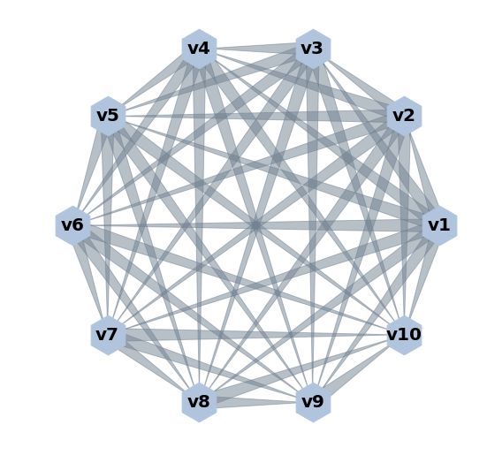

```python
G3 = nx.MultiDiGraph()
plt.figure(figsize=(9,9))

G3.add_edges_from([('v1','v2'), ('v1','v3'), ('v1','v4'), ('v1','v5'), ('v1','v6')])
G3.add_edges_from([('v1','v7'), ('v1','v8'), ('v1','v9'), ('v1','v10')])
G3.add_edges_from([('v2','v3'), ('v2','v4'), ('v2','v5'), ('v2','v6')])
G3.add_edges_from([('v2','v7'), ('v2','v8'), ('v2','v9'), ('v2','v10')])
G3.add_edges_from([('v3','v4'), ('v3','v5'), ('v3','v6')])
G3.add_edges_from([('v3','v7'), ('v3','v8'), ('v3','v9'), ('v3','v10')])
G3.add_edges_from([('v4','v5'), ('v4','v6'), ('v4','v7'), ('v4','v8'), ('v4','v9'), ('v4','v10')])
G3.add_edges_from([('v5','v6'), ('v5','v7'), ('v5','v8'), ('v5','v9'), ('v5','v10')])
G3.add_edges_from([('v6','v7'), ('v6','v8'), ('v6','v9'), ('v6','v10')])
G3.add_edges_from([('v7','v8'), ('v7','v9'), ('v7','v10')])
G3.add_edges_from([('v8','v9'), ('v8','v10')])
G3.add_edges_from([('v9','v10')])

pos=nx.circular_layout(G3)

nx.draw_networkx_edges(G3, pos, width=1,
                       alpha=0.5, edge_color='slategray',
                       arrowsize=50, arrowstyle='wedge')
nx.draw_networkx_nodes(G3, pos, node_size=2000,
                       node_shape='h', node_color='lightsteelblue')
nx.draw_networkx_labels(G3, pos, font_size=20, font_weight='bold')

plt.axis('off')
plt.show()
```

```python
for path in nx.all_simple_paths(G3, 'v1', 'v10', cutoff=3): print (path)
```

```
['v1', 'v2', 'v3', 'v10']
['v1', 'v2', 'v4', 'v10']
['v1', 'v2', 'v5', 'v10']
['v1', 'v2', 'v6', 'v10']
['v1', 'v2', 'v7', 'v10']
['v1', 'v2', 'v8', 'v10']
['v1', 'v2', 'v9', 'v10']
['v1', 'v2', 'v10']
['v1', 'v3', 'v4', 'v10']
['v1', 'v3', 'v5', 'v10']
['v1', 'v3', 'v6', 'v10']
['v1', 'v3', 'v7', 'v10']
['v1', 'v3', 'v8', 'v10']
['v1', 'v3', 'v9', 'v10']
['v1', 'v3', 'v10']
['v1', 'v4', 'v5', 'v10']
['v1', 'v4', 'v6', 'v10']
['v1', 'v4', 'v7', 'v10']
['v1', 'v4', 'v8', 'v10']
['v1', 'v4', 'v9', 'v10']
['v1', 'v4', 'v10']
['v1', 'v5', 'v6', 'v10']
['v1', 'v5', 'v7', 'v10']
['v1', 'v5', 'v8', 'v10']
['v1', 'v5', 'v9', 'v10']
['v1', 'v5', 'v10']
['v1', 'v6', 'v7', 'v10']
['v1', 'v6', 'v8', 'v10']
['v1', 'v6', 'v9', 'v10']
['v1', 'v6', 'v10']
['v1', 'v7', 'v8', 'v10']
['v1', 'v7', 'v9', 'v10']
['v1', 'v7', 'v10']
['v1', 'v8', 'v9', 'v10']
['v1', 'v8', 'v10']
['v1', 'v9', 'v10']
['v1', 'v10']
```

```python
len(list(nx.all_simple_paths(G3, 'v1', 'v10')))
```

```
256
```

1) Рассмотрим случай 𝑛 = 3: 'v1', 'v2', 'v3'.

Подсчитаем возможные варианты дорог: ('v1', 'v2', 'v3'), ('v1', 'v3') - 2 штуки ($2=2^1=2^{n-2}$).

2) 𝑛 = 4: 'v1', 'v2', 'v3', 'v4'.

Возможные варианты дорог: ('v1', 'v2', 'v3', 'v4'), ('v1', 'v3', 'v4'), ('v1', 'v2', 'v4'), ('v1', 'v4') - 4 штуки ($4=2^2=2^{n-2}$).

3) 𝑛 = 5: 'v1', 'v2', 'v3', 'v4', 'v5'.

Возможные варианты дорог: ('v1', 'v2', 'v3', 'v4', 'v5'), ('v1', 'v2', 'v3', 'v5'), ('v1', 'v3', 'v4', 'v5'), ('v1', 'v2', 'v4', 'v5'), ('v1', 'v2', 'v5'), ('v1', 'v3', 'v5'), ('v1', 'v4', 'v5'), ('v1', 'v5') - 8 штук ($8=2^3=2^{n-2}$).

4) 𝑛 = 10: $2^{n-2}=2^8=256$ штук.

```python
answer_dictionary[15]=str(2**8)
print("Answer:", answer_dictionary[15])
```

```
Answer: 256
```

#### Задание 16

В какой системе счисления записано уравнение $𝑥^2 − 30 * 𝑥 + 240 = 0$, если известно, что оно имеет корень кратности 2?

Пусть корень уравнения в исходной системе счисления с основанием p равен $𝑥_0$, тогда:

$[𝑥^2 − 30 * 𝑥 + 240 = 0]_p$ и $[(𝑥 - 𝑥_0)^2 = 𝑥^2 - 2 * 𝑥_0 * 𝑥 + 𝑥_0^2 = 0]_p$.

Соответствующие коэффициенты квадратных уравнений должны быть равны: $[2 * 𝑥_0 = 30]_p$; $[𝑥_0^2 = 240]_p$.

Запишем эти равенства в десятичной системе счисления:

$2 * p^0 * 𝑥_0 = 3 * p^1 + 0 * p^0$; $𝑥_0^2 = 2 * p^2 + 4 * p^1 + 0 * p^0$.

$\large {\frac{9} {4}}$ $ * \ p^2 - 2 * p^2 - 4 * p = 0$ => $ p * (p - 16) = 0$ => $p = 16$

Корень $p = 0$ не подходит по условию задачи, поскольку р является основанием системы счисления.

```python
answer_dictionary[16]=str(16)
print("Answer:", answer_dictionary[16])
```

```
Answer: 16
```

#### Задание 17

В языке запросов поискового сервера для обозначения логической операции «ИЛИ» используется символ «|», а для обозначения логической операции «И» — символ «&». В таблице приведены запросы и количество найденных по ним страниц.

| Запрос $\ \triangleright \ \triangleright \ \triangleright \ \triangleright \ \triangleright$ | Количество страниц $\ \triangleright \ \triangleright \ \triangleright \ \triangleright \ \triangleright$ |
| --- | --- |
| $C \ \& \ Java$ | 8 |
| $C++ \ \& \ Java$ | 18 |
| $C \ \& \ C++$ | 13 |
| $C$ | 23 |
| $Java$ | 33 |
| $C \ \& \ (C++ \ \mid \ Java)$ | 13 |

Какое количество страниц будет найдено по запросу $C \ \mid \ (C++ \ \& \ Java)$?

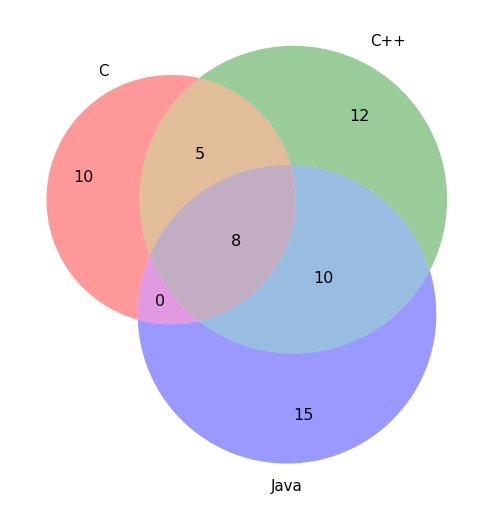

```python
from matplotlib_venn import venn3
plt.figure(figsize=(9,9));

c_and_java = 8
cplus_and_java = 18
c_and_cplus = 13
c = 23
java = 33
c_and_Icplus_or_javaI = 13

c_and_cplus_and_java = c_and_java + c_and_cplus - c_and_Icplus_or_javaI

search_sets =[c - c_and_cplus - c_and_java + c_and_cplus_and_java, 12,
              c_and_cplus - c_and_cplus_and_java,
              java - c_and_java - cplus_and_java + c_and_cplus_and_java,
              c_and_java - c_and_cplus_and_java,
              cplus_and_java - c_and_cplus_and_java,
              c_and_cplus_and_java]

v=venn3(subsets=search_sets, set_labels=('C', 'C++', 'Java'));

for text in v.set_labels:
    text.set_fontsize(15)
for text in v.subset_labels:
    text.set_fontsize(16)
plt.show();
```

```python
c_and_cplus_and_java = c_and_java + c_and_cplus - c_and_Icplus_or_javaI
c_or_Icplus_and_javaI = c + cplus_and_java - c_and_cplus_and_java
c_or_Icplus_and_javaI
```

```
33
```

```python
answer_dictionary[17]=str(33)
print("Answer:", answer_dictionary[17])
```

```
Answer: 33
```

#### Задание 18

На вещественной плоскости $\mathbb{R}^2$ заданы две области: $𝑃 \ (𝑥, 𝑦) = \{𝑦 ≤ 0\}$ и $𝑄 \ (𝑥, 𝑦) = \{︀9 − 𝑥^2 − 𝑦 > 0\}︀$.

Область $𝐴$ такова, что формула $((𝑥, 𝑦) \in 𝑄) \to ((𝑥, 𝑦) \in 𝐴) \lor ((𝑥, 𝑦) \in 𝑃)$ тождественно истинна для любой пары чисел $ (𝑥, 𝑦) \in \mathbb{R}^2$.

Какое наименьшее количество точек целочисленной решётки $\mathbb{Z}^2$ (то есть точек, все координаты которых являются целыми числами) может содержаться в области $𝐴$?

```python
%%latex
$((𝑥, 𝑦) \in 𝑄) \to ((𝑥, 𝑦) \in 𝐴) \lor ((𝑥, 𝑦) \in 𝑃) \iff
\neg ((𝑥, 𝑦) \in 𝑄) \lor ((𝑥, 𝑦) \in 𝐴) \lor ((𝑥, 𝑦) \in 𝑃) \iff \\
\iff \neg (9 − 𝑥^2 − 𝑦 > 0) \lor ((𝑥, 𝑦) \in 𝐴) \lor (𝑦 ≤ 0) \iff
(𝑦 \geq 9 − 𝑥^2) \lor ((𝑥, 𝑦) \in 𝐴) \lor (𝑦 ≤ 0) \ (*)$
```

$((𝑥, 𝑦) \in 𝑄) \to ((𝑥, 𝑦) \in 𝐴) \lor ((𝑥, 𝑦) \in 𝑃) \iff \neg ((𝑥, 𝑦) \in 𝑄) \lor ((𝑥, 𝑦) \in 𝐴) \lor ((𝑥, 𝑦) \in 𝑃) \iff \\ \iff \neg (9 − 𝑥^2 − 𝑦 > 0) \lor ((𝑥, 𝑦) \in 𝐴) \lor (𝑦 ≤ 0) \iff (𝑦 \geq 9 − 𝑥^2) \lor ((𝑥, 𝑦) \in 𝐴) \lor (𝑦 ≤ 0) \ (*)$

```python
%%latex
$ (*) \equiv True \iff ((𝑥, 𝑦) \in 𝐴) \equiv ((𝑦 > 0) \land (𝑦 < 9 − 𝑥^2))$
```

$ (*) \equiv True \iff ((𝑥, 𝑦) \in 𝐴) \equiv ((𝑦 > 0) \land (𝑦 < 9 − 𝑥^2))$

```python
%%latex
$ (𝑥, 𝑦) \in \{(0,1); (0,2); (0,3); (0,4); (0,5); (0,6); (0,7); (0,8); \\
\ \ \ \ \ \ \ \ \ \ \ \ \ \ \ (1,1); (-1,1); (1,2); (-1,2); (1,3); (-1,3); (1,4); (-1,4); \\
\ \ \ \ \ \ \ \ \ \ \ \ \ \ \ (1,5); (-1,5); (1,6); (-1,6); (1,7); (-1,7); \\
\ \ \ \ \ \ \ \ \ \ \ \ \ \ \ (2,1); (-2,1); (2,2); (-2,2); (2,3); (-2,3); (2,4); (-2,4) \}$
```

$ (𝑥, 𝑦) \in \{(0,1); (0,2); (0,3); (0,4); (0,5); (0,6); (0,7); (0,8); \\ \ \ \ \ \ \ \ \ \ \ \ \ \ \ \ (1,1); (-1,1); (1,2); (-1,2); (1,3); (-1,3); (1,4); (-1,4); \\ \ \ \ \ \ \ \ \ \ \ \ \ \ \ \ (1,5); (-1,5); (1,6); (-1,6); (1,7); (-1,7); \\ \ \ \ \ \ \ \ \ \ \ \ \ \ \ \ (2,1); (-2,1); (2,2); (-2,2); (2,3); (-2,3); (2,4); (-2,4) \}$

```python
answer_dictionary[18]=str(30)
print("Answer:", answer_dictionary[18])
```

```
Answer: 30
```

#### Задание 19

В программе используется одномерный целочисленный массив $𝐴$ с индексами от $0$ до $9$.

Значения элементов равны $15; 3; 54; 13; 2; 13; 65; 93; 21; 81$ соответственно, т.е. $𝐴[0] = 15$; $𝐴[1] = 3$ и т. д.

Определите значение переменной $𝑘$ после выполнения следующего фрагмента программы, записанного ниже на разных языках программирования.

Паскаль

Си http://cpp.sh/

Бейсик

Python

```bash
k := 0;
for i := 0 to 9 do begin
    m := A[i] div 10 mod 10;
    if i > m then begin
        k := k + 1;
        A[i] := A[9 - m]
    end
end;
```

```bash
k = 0;
for (i = 0; i < 10; i++) {
    m = A[i] / 10 % 10;
    if (i > m) {
        k++;
        A[i] = A[9 - m];
    }
}
```

```bash
K = 0
FOR I = 0 TO 9
    M = A(I) \ 10 MOD 10
    IF I > M THEN
        K = K + 1
        A(I) = A(9 - M)
    END IF
NEXT I
```

```bash
k = 0
for i in range(10) :
    m = A[i] // 10 % 10
    if i > m :
        k += 1
        A[i] = A[9 - m]
```

```python
import numpy
A = numpy.array([15, 3, 54, 13, 2, 13, 65, 93, 21, 81])
k = 0
for i in range(10):
    m = A[i] // 10 % 10
    if i > m :
        k += 1
        A[i] = A[9 - m]

answer_dictionary[19]=str(k)
print("Answer:", answer_dictionary[19])
```

```
Answer: 6
```

#### Задание 20

Укажите наименьшее натуральное число $𝑥$, при вводе которого будут напечатаны числа $3$ и $2$.

Паскаль

Си http://cpp.sh/

Бейсик

Python

```bash
var x, d, a, b : integer;
begin
    read(x);
    a := 0; b := 0; d := 5;
    while x > 0 do begin
        if x mod 10 > d then
            a := a + 1
        else
            b := b + 1;
        d := x mod 10;
        x := x div 10
    end;
    writeln(a, ’ ’, b)
end;
```

```bash
#include <stdio.h>
void main() {
    int x, a = 0, b = 0, d = 5;
    scanf("%d", &x);
    while (x > 0) {
        if (x % 10 > d)
            a++;
        else
            b++;
        d = x % 10;
        x /= 10;
    }
    printf("%d %d", a, b);
}
```

```bash
DIM X, D, A, B AS INTEGER
INPUT X
A = 0 : B = 0 : D = 5
WHILE X > 0
    IF X MOD 10 > D THEN
        A = A + 1
    ELSE
        B = B + 1
    END IF
    D = X MOD 10
    X = X \ 10
WEND
PRINT A, " ", B
```

```bash
x = int(input())
a = b = 0
d = 5
while x > 0:
    if x % 10 > d:
        a += 1
    else:
        b += 1
    d = x % 10
    x //= 10
print(a, b)
```

```python
for x in range(10070,10080):
    t = x
    a = b = 0
    d = 5
    while x > 0:
        if x % 10 > d:
            a += 1
        else:
            b += 1
        d = x % 10
        x //= 10
    if a == 3 and b == 2:
        answer_dictionary[20]=str(t)
    print(t, a, b)

print("\nAnswer:", answer_dictionary[20])
```

```
10070 2 3
10071 2 3
10072 2 3
10073 2 3
10074 2 3
10075 2 3
10076 3 2
10077 2 3
10078 2 3
10079 2 3

Answer: 10076
```

Программа подсчитывает и сохраняет в качестве переменной $a$ количество цифр в числе, больших $5$ или превосходящих следующую цифру, в качестве переменной $b$ - остальные цифры числа. Анализ цифр начинается с последнего разряда.

Для выполнения условия задачи требуется пятизначное число, причем минимально возможное. Три цифры из $5$ должны превосходить $5$ или последующую.

Если в последнем пятом разряде будет $6 \ (6 > 5)$, а в четвертом $7 \ (7 > 6)$, то переменные после обработки этих цифр алгоритмом будут иметь значения: $a = 2$, $b = 0$. Если в первом разряде будет $1 \ (1 > 0)$, а во втором и третьем - $0$, то $a = 3$, $b = 2$, а число станет минимально возможным.

#### Задание 21

Укажите количество значений входной переменной $𝑘$, при которых программа напечатает тот же ответ, что и при $𝑘 = 12$.

Паскаль

Си http://cpp.sh/

Бейсик

Python

```bash
function f(n : integer) : integer;
begin
    if n > 0 then
        f := 2 * f(n - 1)
    else
        f := 1
end;

var k, i : integer;
begin
    readln(k);
    i := 1;
    while f(i) < k * k do begin
        i := i + 1; k := k + 1
    end;
    writeln(i)
end;
```

```bash
#include <stdio.h>
int f(int n) {
    if (n > 0)
        return 2 * f(n - 1);
    else
        return 1;
}

void main() {
    int k, i = 1;
    scanf("%d", &k);
    while (f(i) < k * k) {
        i++;
        k++;
    }
    printf("%d", i);
}
```

```bash
DIM K, I AS INTEGER
INPUT K : I = 1

WHILE F(I) < K * K
    I = I + 1 : K = K + 1
WEND
PRINT I

FUNCTION F(N)
    IF N > 0 THEN
        F = 2 * F(N - 1)
    ELSE
        F = 1
    END IF
END FUNCTION
```

```bash
def f(n) :
    if n > 0 :
        return 2 * f(n - 1)
    else :
        return 1

k = int(input())
i = 1
while f(i) < k * k :
    i += 1
    k += 1
print(i)
```

1) Определим результат работы алгоритма, если 𝑘 = 12:

- $i=1, k=12, \ f(i) < k * k \iff 2^1 < 12 * 12 - TRUE$
- $i=2, k=13, \ f(i) < k * k \iff 2^2 < 13 * 13 - TRUE$
- $i=3, k=14, \ f(i) < k * k \iff 2^3 < 14 * 14 - TRUE$
- $i=4, k=15, \ f(i) < k * k \iff 2^4 < 15 * 15 - TRUE$
- $i=5, k=16, \ f(i) < k * k \iff 2^5 < 16 * 16 - TRUE$
- $i=6, k=17, \ f(i) < k * k \iff 2^6 < 17 * 17 - TRUE$
- $i=7, k=18, \ f(i) < k * k \iff 2^7 < 18 * 18 - TRUE$
- $i=8, k=19, \ f(i) < k * k \iff 2^8 < 19 * 19 - TRUE$
- $i=9, k=20, \ f(i) < k * k \iff 2^9 < 20 * 20 - FALSE$

2) Такой же результат программа выдаст при $𝑘 = 10, 11, 13$ и $14$. При этом неравенства, приводящее к завершению работы программы, будут иметь вид: $2^9 < 18 * 18, 2^9 < 19 * 19, 2^9 < 21 * 21, 2^9 < 22 * 22$ соответственно.

3) Легко видеть, что при $𝑘 < 10$ переменная $i < 9$, а при $𝑘 > 14$ результат работы программы $i > 9$.

```python
def f(n) :
    if n > 0 :
        return 2 * f(n - 1)
    else :
        return 1
c=0
for k in range(1,20):
    t = k
    i = 1
    while f(i) < k * k :
        i += 1
        k += 1
    print(t,i)
    if i==9: c+=1
```

```
1 1
2 6
3 6
4 7
5 7
6 8
7 8
8 8
9 8
10 9
11 9
12 9
13 9
14 9
15 10
16 10
17 10
18 10
19 10
```

```python
answer_dictionary[21]=str(c)
print("Answer:", answer_dictionary[21])
```

```
Answer: 5
```

#### Задание 22

Для некоторого исполнителя, преобразующего число на экране, определены две команды:

1) прибавить 2;

2) прибавить сумму цифр.

Первая из них увеличивает число на экране на 2, вторая увеличивает это число на сумму его цифр. Программа для исполнителя — это последовательность команд.

Сколько существует программ, для которых при исходном числе 10 результатом является число 36, при этом траектория вычислений не содержит палиндромов (то есть чисел, одинаково читающихся в обоих направлениях)?

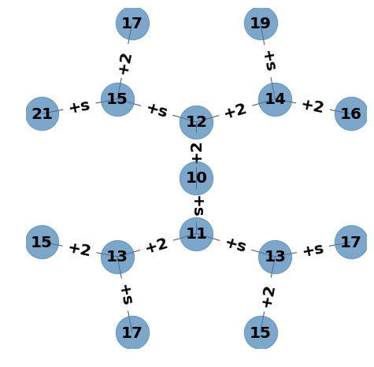

```python
G4 = nx.balanced_tree(2, 3)
pos = graphviz_layout(G4, prog='twopi', args='')
plt.figure(figsize=(6, 6))

node_labels={0:10, 1:12, 2:11, 3:14, 4:15, 5:13, 6:13,
             7:16, 8:19, 9:17, 10:21, 11:15, 12:17, 13:15, 14:17}
edge_labels={(0,1):'+2', (0,2):'+s', (1,3):'+2', (1,4):'+s', (2,5):'+2', (2,6):'+s',
             (3,7):'+2', (3,8):'+s', (4,9):'+2', (4,10):'+s', (5,11):'+2', (5,12):'+s',
             (6,13):'+2', (6,14):'+s'}

nx.draw(G4, pos, node_size=1800, alpha=0.7, node_color="steelblue")
nx.draw_networkx_labels(G4, pos, node_labels, font_size=20, font_weight='bold')
nx.draw_networkx_edge_labels(G4, pos, edge_labels, font_size=20, font_weight='bold')
plt.axis('equal')
plt.show()
```

1) Программы-последовательности не могут начинаться с команды `2` (10->11), т.к. во всех этих цепочках будет присутствовать палиндром 11.

2) Алгоритм не может состоять только из команд вида `1` (10->12->14->...->36), т.к. в цепочке чисел будет присутствовать палиндром 22.

3) Возможные последовательности команд:

- `12111 2111111`: 10->12->15->17->19->21 ->24->26->28->30->32->34->36
- `12111 22111`: 10->12->15->17->19->21 ->24->30->32->34->36
- `12111 2121`: 10->12->15->17->19->21 ->24->26->34->36
- `12111 11211`: 10->12->15->17->19->21 ->23->25->32->34->36
- `12111 1112`: 10->12->15->17->19->21 ->23->25->27->36
- `12111 121111`: 10->12->15->17->19->21 ->23->28->30->32->34->36

Аналогично:

- `1121 2111111`: 10->12->14->19->21 ->24->26->28->30->32->34->36
- `1121 22111`: 10->12->14->19->21 ->24->30->32->34->36
- `1121 2121`: 10->12->14->19->21 ->24->26->34->36
- `1121 11211`: 10->12->14->19->21 ->23->25->32->34->36
- `1121 1112`: 10->12->14->19->21 ->23->25->27->36
- `1121 121111`: 10->12->14->19->21 ->23->28->30->32->34->36

Аналогично:

- `122 2111111`: 10->12->15->21 ->24->26->28->30->32->34->36
- `122 22111`: 10->12->15->21 ->24->30->32->34->36
- `122 2121`: 10->12->15->21 ->24->26->34->36
- `122 11211`: 10->12->15->21 ->23->25->32->34->36
- `122 1112`: 10->12->15->21 ->23->25->27->36
- `122 121111`: 10->12->15->21 ->23->28->30->32->34->36
- `1212 211`: 10->12->15->17->25 ->32->34->36
- `1212 12`: 10->12->15->17->25 ->27->36
- `1112 1211`: 10->12->14->16->23 ->25->32->34->36
- `1112 112`: 10->12->14->16->23 ->25->27->36
- `1112 21111`: 10->12->14->16->23 ->28->30->32->34->36
- `1111 22`: 10->12->14->16->18 ->27->36

4) Всего 24 программы.

```python
answer_dictionary[22]=str(24)
print("Answer:", answer_dictionary[22])
```

```
Answer: 24
```

#### Задание 23

Сколько существует различных наборов значений логических переменных $𝑥_1, . . . , 𝑥_{10}$, при которых следующие выражения истинны?

$(𝑥_1 \to 𝑥_2) \land (𝑥_2 \to 𝑥_1) \land (𝑥_3 \to 𝑥_4)$,

$(𝑥_4 \to 𝑥_3) \land (𝑥_5 \to 𝑥_6) \land (𝑥_5 \to 𝑥_1)$,

$(𝑥_6 \to 𝑥_5) \land (𝑥_7 \to 𝑥_8) \land (𝑥_8 \to 𝑥_7)$,

$(𝑥_9 \to 𝑥_{10}) \land (𝑥_1 \equiv 𝑥_4)$.

```python
%%latex
$\begin{cases}
(𝑥_1 \to 𝑥_2) \land (𝑥_2 \to 𝑥_1) \land (𝑥_3 \to 𝑥_4) = 1 \\
(𝑥_4 \to 𝑥_3) \land (𝑥_5 \to 𝑥_6) \land (𝑥_5 \to 𝑥_1) = 1\\
(𝑥_6 \to 𝑥_5) \land (𝑥_7 \to 𝑥_8) \land (𝑥_8 \to 𝑥_7) = 1\\
(𝑥_9 \to 𝑥_{10}) \land (𝑥_1 \equiv 𝑥_4) = 1
\end{cases} \iff \\ \\ \\

(𝑥_1 \to 𝑥_2) \land (𝑥_2 \to 𝑥_1) \land (𝑥_3 \to 𝑥_4)
\land (𝑥_4 \to 𝑥_3) \land (𝑥_5 \to 𝑥_6) \land (𝑥_5 \to 𝑥_1)
\land (𝑥_6 \to 𝑥_5) \land (𝑥_7 \to 𝑥_8) \land (𝑥_8 \to 𝑥_7)
\land (𝑥_9 \to 𝑥_{10}) \land (𝑥_1 \equiv 𝑥_4) = 1 \\ \\ \\

\iff (𝑥_1 \equiv 𝑥_2) \land (𝑥_3 \equiv 𝑥_4) \land (𝑥_5 \equiv 𝑥_6) \land (𝑥_7 \equiv 𝑥_8)
\land (𝑥_5 \to 𝑥_1) \land (𝑥_9 \to 𝑥_{10}) \land (𝑥_1 \equiv 𝑥_4) = 1 \iff \\ \\ \\

\iff (𝑥_1 \equiv 𝑥_2 \equiv 𝑥_3 \equiv 𝑥_4) \land (𝑥_5 \equiv 𝑥_6) \land (𝑥_7 \equiv 𝑥_8)
\land (𝑥_5 \to 𝑥_1) \land (𝑥_9 \to 𝑥_{10}) = 1 \iff \\

\iff \begin{cases}
(𝑥_1 \equiv 𝑥_2 \equiv 𝑥_3 \equiv 𝑥_4) \land (𝑥_5 \equiv 𝑥_6) \land (𝑥_5 \to 𝑥_1) = 1 \ (1) \\
𝑥_7 \equiv 𝑥_8 = 1 \ (2) \\
𝑥_9 \to 𝑥_{10} = 1 \ (3)
\end{cases}$
```

$\begin{cases} (𝑥_1 \to 𝑥_2) \land (𝑥_2 \to 𝑥_1) \land (𝑥_3 \to 𝑥_4) = 1 \\ (𝑥_4 \to 𝑥_3) \land (𝑥_5 \to 𝑥_6) \land (𝑥_5 \to 𝑥_1) = 1\\ (𝑥_6 \to 𝑥_5) \land (𝑥_7 \to 𝑥_8) \land (𝑥_8 \to 𝑥_7) = 1\\ (𝑥_9 \to 𝑥_{10}) \land (𝑥_1 \equiv 𝑥_4) = 1 \end{cases} \iff \\ \\ \\ (𝑥_1 \to 𝑥_2) \land (𝑥_2 \to 𝑥_1) \land (𝑥_3 \to 𝑥_4) \land (𝑥_4 \to 𝑥_3) \land (𝑥_5 \to 𝑥_6) \land (𝑥_5 \to 𝑥_1) \land (𝑥_6 \to 𝑥_5) \land (𝑥_7 \to 𝑥_8) \land (𝑥_8 \to 𝑥_7) \land (𝑥_9 \to 𝑥_{10}) \land (𝑥_1 \equiv 𝑥_4) = 1 \\ \\ \\ \iff (𝑥_1 \equiv 𝑥_2) \land (𝑥_3 \equiv 𝑥_4) \land (𝑥_5 \equiv 𝑥_6) \land (𝑥_7 \equiv 𝑥_8) \land (𝑥_5 \to 𝑥_1) \land (𝑥_9 \to 𝑥_{10}) \land (𝑥_1 \equiv 𝑥_4) = 1 \iff \\ \\ \\ \iff (𝑥_1 \equiv 𝑥_2 \equiv 𝑥_3 \equiv 𝑥_4) \land (𝑥_5 \equiv 𝑥_6) \land (𝑥_7 \equiv 𝑥_8) \land (𝑥_5 \to 𝑥_1) \land (𝑥_9 \to 𝑥_{10}) = 1 \iff \\ \iff \begin{cases} (𝑥_1 \equiv 𝑥_2 \equiv 𝑥_3 \equiv 𝑥_4) \land (𝑥_5 \equiv 𝑥_6) \land (𝑥_5 \to 𝑥_1) = 1 \ (1) \\ 𝑥_7 \equiv 𝑥_8 = 1 \ (2) \\ 𝑥_9 \to 𝑥_{10} = 1 \ (3) \end{cases}$

1) (1) выполняется для 3 вариантов $(x_1,x_2,x_3,x_4,x_5,x_6)$: (0,0,0,0,0,0), (1,1,1,1,0,0), (1,1,1,1,1,1).

2) (2) выполняется для 2 вариантов $(x_7,x_8)$: (0,0), (1,1).

3) (3) выполняется для 3 вариантов $(x_9,x_{10})$: (0,0), (0,1), (1,1).

4) Решениями системы (1), (2), (3) могут быть любые перечисленные сочетания $(x_1,x_2,x_3,x_4,x_5,x_6)$, $(x_7,x_8)$, $(x_9,x_{10})$.

Их общее количество: $3 * 2 * 3 = 18$.

```python
# check the decision method
import itertools
from sympy.logic.boolalg import Implies
n = 10
binary_combinations = numpy.array(list(itertools.product([0, 1], repeat=n)))
result = []

for el in binary_combinations:
    e1 = Implies(el[0],el[1]) and Implies(el[1],el[0]) and Implies(el[2],el[3])
    e2 = Implies(el[3],el[2]) and Implies(el[4],el[5]) and Implies(el[4],el[0])
    e3 = Implies(el[5],el[4]) and Implies(el[6],el[7]) and Implies(el[7],el[6])
    e4 = Implies(el[8],el[9]) and (el[0] == el[3])
    result.append(e1 == True and e2 == True and e3 == True and e4 == True)

answer_dictionary[23]=str(sum(result))
print("Answer:", answer_dictionary[23])
```

```
Answer: 18
```

## Часть 2 Part 2

#### Задание 24

Требовалось написать программу, которая по входному натуральному числу 𝑛, не превосходящему 104, определяла и печатала количество различных делителей этого числа (включая единицу и само число 𝑛).

Приведённая ниже программа содержит ошибки.

Последовательно выполните следующее.

1) Напишите, что выведет эта программа при вводе числа 10.

2) Укажите два наименьших значения входной переменной 𝑛, при которых программа выведет верный ответ.

3) Найдите в программе все ошибки (их может быть одна или несколько).

Для каждой ошибки выпишите строку, в которой она допущена, и приведите эту же строку в исправленном виде. Достаточно указать ошибки и способ их исправления для одного языка программирования. Обратите внимание: необходимо исправить приведённую программу, а не написать свою. Требуется заменить только ошибочные строки, но нельзя удалять строки или добавлять новые. За исправления, внесённые в строки, не содержащие ошибок, баллы будут снижаться.

Паскаль

Си http://cpp.sh/

Бейсик

Python

```bash
var
    n, j, k : integer;
begin
    read(n);
    j := 2;
    k := 0;

    while j * j < n do begin
        if n mod j = 0 then
            k := k + 2;
        j := j + 1
    end;

    if j * j = n then
        k := k + 3;
    write(k)
end;
```

```bash
#include <stdio.h>
void main() {
    int n, j, k;
    scanf("%d", &n);
    j = 2;
    k = 0;

    while (j * j < n) {
        if (n % j == 0)
            k += 2;
        j++;
    }
    if (j * j == n)
        k += 3;
    printf("%d", k);
}
```

```bash
DIM N, J, K AS INTEGER
INPUT N
J = 2
K = 0

WHILE J * J < N
    IF N MOD J = 0 THEN
        K = K + 2
    END IF
    J = J + 1
WEND
IF J * J = N THEN
    K = K + 3
END IF
PRINT K
```

```bash
n = int(input())
j = 2
k = 0

while j * j < n :
    if n % j == 0 :
        k += 2
    j += 1
if j * j == n :
    k += 3
print(k)
```

```python
# the wrong version - the wrong answer
n = int(input())
j = 2
k = 0

while j * j < n :
    if n % j == 0 :
        k += 2
    j += 1
if j * j == n :
    k += 3
print(k)
```

```
10
2
```

```python
# the wrong version - the right answer
n = int(input())
j = 2
k = 0

while j * j < n :
    if n % j == 0 :
        k += 2
    j += 1
if j * j == n :
    k += 3
print(k)
```

```
4
3
```

```python
# the wrong version - the right answer
n = int(input())
j = 2
k = 0

while j * j < n :
    if n % j == 0 :
        k += 2
    j += 1
if j * j == n :
    k += 3
print(k)
```

```
9
3
```

```python
# the right version - the right answer
n = int(input())
j = 1
k = 0

while j * j < n :
    if n % j == 0 :
        k += 2
    j += 1
if j * j == n :
    k += 1
print(k)
```

```
12
6
```

```python
answer1 = """1. 2;"""
answer2 = """2. 𝑛 = 4,9 => k=3 (правильный результат)"""
answer3 = """3. Python: 'j = 2' -> 'j = 1'; 'k += 3' -> 'k += 1'"""
answer_dictionary[24]=[answer1, answer2, answer3]
print("Answer:", answer_dictionary[24])
```

```
Answer: ['1. 2;', '2. 𝑛 = 4,9 => k=3 (правильный результат)', "3. Python: 'j = 2' -> 'j = 1'; 'k += 3' -> 'k += 1'"]
```

#### Задание 25

Дан массив, содержащий 2017 целых чисел. Необходимо определить моду значений элементов этого массива, то есть значение, которое встречается чаще всего. Если таких значений несколько, необходимо вывести наименьшее из них. Например, в массиве из 6 элементов, равных соответственно 2; 0; 1; 0; 3; 1, модой являются значения 0 и 1, значит, ответом будет 0 — наименьшее из них. Исходные данные объявлены так, как показано ниже. Запрещается использовать не описанные переменные, но допускается не использовать некоторые из них.

В качестве ответа необходимо привести фрагмент программы, который должен находиться на месте многоточия. Допускается решение на другом языке программирования. В этом случае укажите название языка и используемую версию. При этом необходимо использовать те же самые исходные данные и переменные, какие были предложены в условии.

Паскаль

Си http://cpp.sh/

Бейсик

Python

```bash
const
    N = 2017;
var
    a : array [0..N - 1] of integer;
    i, j, m, p, s : integer;
begin
    for i := 0 to N - 1 do
        readln(a[i]);
    ...
end;
```

```bash
#include <stdio.h>
#define N 2017

int main() {
    int a[N];
    int i, j, m, p, s;
    for (i = 0; i < N; i++)
        scanf("%d", &a[i]);
    ...
return 0;
}
```

```bash
CONST N = 2017
DIM A(N - 1), I, J, M, P, S AS INTEGER
FOR I = 0 to N - 1
    INPUT A(I)
NEXT I
...
END
```

```bash
# допускается также использование
# целочисленных переменных j, m, p, s
N = 2017
a = []
for i in range(N) :
    a.append(int(input()))
...
```

```python
"""
N = 2017
a = []
for i in range(N) :
    a.append(int(input()))"""
# Для тестирования случайным образом генерируется массив из 2017 целых чисел
N = 2017
a = numpy.random.randint(1000, size=N)
a.shape
```

```
(2017,)
```

```python
p = 1
for i in range(N) :
    s = 1
    for j in range(N) :
        if a[j] == a[i] :
            s += 1
        if s > p :
            m = a[i]
            p = s
        else :
            if p == s and m > a[i]:
                m = a[i]
print(m)
```

```
328
```

```python
# Проверка решения
import pandas
unique = pandas.value_counts(pandas.Series(a))
unique.where(unique.values == unique.max()).dropna().sort_index().index[0]
```

```
328
```

```python
import sys
version = 'python '+str(sys.version_info[0])+'.'+str(sys.version_info[1])
program_fragment = \
"""
p = 1
for i in range(N) :
    s = 1
    for j in range(N) :
        if a[j] == a[i] :
            s += 1
        if s > p :
            m = a[i]
            p = s
        else :
            if p == s and m > a[i]:
                m = a[i]
print(m)
"""
```

```python
answer_dictionary[25]=[version, program_fragment]
print("Answer:", answer_dictionary[25])
```

```
Answer: ['python 3.6', '\np = 1\nfor i in range(N) :\n    s = 1\n    for j in range(N) :\n        if a[j] == a[i] :\n            s += 1\n        if s > p :\n            m = a[i]\n            p = s\n        else :\n            if p == s and m > a[i]:\n                m = a[i]\nprint(m)\n']
```

#### Задание 26

Однажды утром мистер Блэк, мистер Грей и мистер Уайт задумали решить конфликт труэлью на пистолетах. Стрелять условились до тех пор, пока в живых не останется только один из участников. Мистер Уайт стрелял хуже всех: в цель он попадал в среднем лишь один раз из трёх. Мистер Грей в среднем попадал в цель два раза из трёх, а мистер Блэк стрелял лучше всех — без промаха. Чтобы уравнять шансы участников труэли, мистеру Уайту разрешено стрелять первым, за ним должен стрелять мистер Грей (если он останется в живых), затем мог стрелять мистер Блэк (если он ещё будет жив). Далее все начиналось снова, и так до тех пор, пока в живых не останется только один из участников труэли.

Выполните следующие задания. Во всех случаях обосновывайте свой ответ.

1) В кого из участников труэли должен произвести первый выстрел мистер Блэк (если право хода дойдёт до него), чтобы его шансы выиграть труэль были максимальны? Укажите первый ход мистера Блэка для каждой из возможных ситуаций и соответвующую вероятность победы в труэли.

2) В кого из участников труэли должен произвести первый выстрел мистер Грей (если право хода дойдёт до него), чтобы его шансы выиграть труэль были максимальны? Укажите первый ход мистера Грея для каждой из возможных ситуаций и соответвующую вероятность победы в труэли.

3) В кого из участников труэли должен произвести первый выстрел мистер Уайт, чтобы его шансы выиграть труэль были максимальны? Укажите первый ход мистера Уайта и соответвующую вероятность победы в труэли.

$1$. Вероятность выигрыша и стратегии Блэка (третий ход).

| Номер | Возможная позиция | Стратегия Блэка | Вероятность выигрыша Блэка |
| --- | --- | --- | --- |
|  |  | 1.1 выстрел Блэка в Грея (Грей стреляет лучше, но он сразу убит) |  |
| 1 | Грей и Уайт живы | 1.2 выстрел Уайта с вероятностью успеха 1/3 | 2/3 |
|  |  | 1.3 выстрел Блэка (Уайт убит) |  |
| 2 | Грей убит, Уайт жив | выстрел Блэка (Уайт убит) | 1 |
| 3 | Уайт убит, Грей жив | выстрел Блэка (Грей убит) | 1 |

$2$. Вероятность выигрыша и стратегии Грея (второй ход).

| Номер | Возможная позиция | Стратегия Грея | Вероятность выигрыша Грея |
| --- | --- | --- | --- |
|  |  | 1.1 выстрел Грея в Блэка с вероятностью попадания 2/3 |  |
| 1 | Блэк и Уайт живы | 1.2 выстрел Уайта с вероятностью промаха 1 - 1/3 | $(\frac{2}{3})^3 = \frac{8}{27}$ |
|  |  | 1.3 выстрел Грея в случае промаха Уайта с вероятностью попадания 2/3 ... |  |
| 2 | Блэк убит, Уайт жив | выстрел Грея в Уайта с вероятностью попадания 2/3 | 2/3 |

$3$. Вероятность выигрыша и стратегия Уайта (первый ход).

- 3.1. Выстрел Уайта в воздух: у более опасных противников выше вероятность попасть друг в друга.
- 3.2. Стреляет Грей в более опасного противника Блэка и попадает с вероятностью 2/3.
- 3.3. Стреляет Блэк (если остался в живых с вероятностью 1/3) в более опасного противника Грея и попадает с вероятностью 1.
- 3.4. Уайт стреляет в оставшегося в живых соперника и попадает с вероятностью 1/3. Его выигрыш в данной ситуации не зависит от результатов предыдущих выстрелов Грея и Блэка. При промахе с вероятностью 2/3 шансы Уайта выиграть резко снизятся.

```python
answer = \
'''
$1$. Вероятность выигрыша и стратегии Блэка (третий ход).

| Номер | Возможная позиция | Стратегия Блэка | Вероятность выигрыша Блэка |
|-|-|-|-|
|  |  | 1.1 выстрел Блэка в Грея (Грей стреляет лучше, но он сразу убит)  | |
| 1 | Грей и Уайт живы | 1.2 выстрел Уайта с вероятностью успеха 1/3 | 2/3 |
|  |  | 1.3 выстрел Блэка (Уайт убит)  |  |
| 2 | Грей убит, Уайт жив | выстрел Блэка (Уайт убит) | 1 |
| 3 | Уайт убит, Грей жив | выстрел Блэка (Грей убит) | 1 |

$2$. Вероятность выигрыша и стратегии Грея (второй ход).

| Номер | Возможная позиция | Стратегия Грея | Вероятность выигрыша Грея |
|-|-|-|-|
|  |  | 1.1 выстрел Грея в Блэка с вероятностью попадания 2/3  | |
| 1 | Блэк и Уайт живы | 1.2 выстрел Уайта с вероятностью промаха 1 - 1/3 | $(\frac{2}{3})^3 = \frac{8}{27}$ |
|  |  | 1.3 выстрел Грея в случае промаха Уайта с вероятностью попадания 2/3 ...  |  |
| 2 | Блэк убит, Уайт жив | выстрел Грея в Уайта с вероятностью попадания 2/3 | 2/3 |

$3$. Вероятность выигрыша и стратегия Уайта (первый ход).

- 3.1. Выстрел Уайта в воздух: у более опасных противников выше вероятность попасть друг в друга.

- 3.2. Стреляет Грей в более опасного противника Блэка и попадает с вероятностью 2/3.

- 3.3. Стреляет Блэк (если остался в живых с вероятностью 1/3) в более опасного противника Грея и попадает с вероятностью 1.

- 3.4. Уайт стреляет в оставшегося в живых соперника и попадает с вероятностью 1/3.

Его выигрыш в данной ситуации не зависит от результатов предыдущих выстрелов Грея и Блэка.

При промахе с вероятностью 2/3 шансы Уайта выиграть резко снизятся.
'''
```

```python
answer_dictionary[26]=[answer]
print("Answer:", answer_dictionary[26])
```

```
Answer: ['\n$1$. Вероятность выигрыша и стратегии Блэка (третий ход).\n\n| Номер | Возможная позиция | Стратегия Блэка | Вероятность выигрыша Блэка |\n|-|-|-|-|\n|  |  | 1.1 выстрел Блэка в Грея (Грей стреляет лучше, но он сразу убит)  | |\n| 1 | Грей и Уайт живы | 1.2 выстрел Уайта с вероятностью у…
```

#### Задание 27

Дан набор из 𝑁 натуральных чисел. Необходимо определить количество пар элементов $\large{(𝑎_𝑖, 𝑎_𝑗)}$ этого набора, в которых $1 ≤ 𝑖 < 𝑗 ≤ 𝑁$ и сумма элементов кратна 12. Напишите эффективную по времени и по памяти программу для решения этой задачи. Программа считается эффективной по времени, если при увеличении количества исходных чисел 𝑁 в 𝑘 раз время работы программы увеличивается не более чем в 𝑘 раз. Программа считается эффективной по памяти, если память, необходимая для хранения переменных программы, не превышает одного килобайта и не увеличивается с ростом 𝑁.

*Описание входных и выходных данных*

В первой строке входных данных задаётся количество чисел 𝑁 (1 ≤ 𝑁 ≤ 10000). В каждой из последующих 𝑁 строк записано одно натуральное число, не превышающее 1000.

*Пример входных данных*:

- 5
- 7
- 5
- 6
- 12
- 24

*Пример выходных данных для приведённого выше примера входных данных*:

- 2

В приведённом наборе из 5 чисел имеются две пары (7, 5) и (12, 24), сумма элементов которых кратна 12.

*Замечание*:

$\mathit{(x+y) \mod 12 \equiv 0 \iff (x \mod 12) + (y \mod 12) \equiv 0}$

Сумма двух чисел кратна 12, если сумма остатков от деления на 12 этих чисел также кратна 12. Это утверждение легко доказать, представив каждое из слагаемых в виде $12*a + b$, где a - результат целочисленного деления на 12, b - остаток.

```python
# Для тестирования случайным образом генерируется массив целых чисел
A = numpy.random.randint(1000, size=100)
A
```

```
array([931, 492, 709, 697, 164, 978, 323, 578, 961, 992, 433, 568, 195,
        57, 137, 109, 859, 290,  46, 621, 724, 863,   0, 845, 703, 845,
       377, 526, 383, 481, 666, 918, 903, 415, 429, 953, 648, 357, 523,
       650,  49, 805,  87, 215, 407, 380, 268, 642, 982, 963, 302, 837,
       831, 944, 528, 973, 958, 835, 538, 680, 902, 510, 130, 771, 951,
       250, 831, 581, 614, 419, 488, 312, 972, 218, 374, 464, 600, 280,
       911,  88, 791, 862, 277,  32, 602, 756, 737, 506, 907, 313, 820,
       804, 848,  86, 997, 621, 554, 468, 723, 645])
```

```python
# Variant 1
M = A % 12
s = 0
for i in range(len(M)):
    if M[i] == 0:
        s+=(M[i+1:] == 0).sum()
    for j in range(1,12):
        if M[i] == j:
            s+=(M[i+1:] == 12-j).sum()

print('Number of pairs:', s)
```

```
Number of pairs: 413
```

```python
# Variant 2
M = A % 12
M.sort()

unique_values, counts = numpy.unique(M, return_counts=True)
s = int((counts[0] * (counts[0] - 1) + counts[6] * (counts[6] - 1))/2)
for j in range(1,6):
    s += counts[j]*counts[12-j]

print('Number of pairs:', s)
```

```
Number of pairs: 413
```

```python
program=\
"""
N = int(input("Количество натуральных чисел: "))
A = numpy.zeros(N)
for i in range(N) :
    A[i] = int(input())

M = A % 12
M.sort()

unique_values, counts = numpy.unique(M, return_counts=True)
s = int((counts[0] * (counts[0] - 1) + counts[6] * (counts[6] - 1))/2)
for j in range(1,6):
    s += counts[j]*counts[12-j]

print('Number of pairs:', s)
"""
```

```python
answer_dictionary[27]=[version, program]
print("Answer:", answer_dictionary[27])
```

```
Answer: ['python 3.6', '\nN = int(input("Количество натуральных чисел: "))\nA = numpy.zeros(N)\nfor i in range(N) :\n    A[i] = int(input())\n\nM = A % 12\nM.sort()\n\nunique_values, counts = numpy.unique(M, return_counts=True)\ns = int((counts[0] * (counts[0] - 1) + counts[6] * (counts[6] - 1))/2)\…
```

## Ответы Answers

```python
answer_dictionary
```

```
{1: '3404',
 2: '5',
 3: '12',
 4: '1',
 5: '15',
 6: '42211',
 7: '16',
 8: '1020',
 9: '192',
 10: '1280',
 11: '5',
 12: '8',
 13: '6',
 14: '28',
 15: '256',
```

[output cut: 16 more lines]